### UNICAN-UIMP Master on Particle Physics and Cosmos. 2019-2020

# Writing and reading columnar data

This is a Python notebook in which you will practice the concepts learned during the lectures.

## Startup ROOT

Import the ROOT module: this will activate the integration layer with the notebook automatically

```python
import ROOT
import numpy as np
```

```
Welcome to JupyROOT 6.12/07
```

## Writing and Reading NTuple

Create a **TFile** containing an `TNtuple` `(x,y,z,t)` filled with random numbers distributed according to a uniform, gaus, exponential and a Landau distribution. Close the file: you will reopen it later.

```python
rndm = ROOT.TRandom3(1)

filename = "ntuple_example.root"

# Create the File

file1 = ROOT.TFile(filename, 'RECREATE')

# Here create the Ntuple. The ntuple must be stored as "n" with the arrays "x:y:z:t"
ntuple = ROOT.TNtuple('n', 'n', 'x:y:z:t')

# Here create the arrays x,y,z and t and assign random values
n = 10000

x = np.random.uniform(-10,10,n)

# y is a normal with mean=0 and sigma=5
y = np.random.normal(0,5,n)

# z is an exponential with scale=10
z = np.random.exponential(10,n)

t = np.array(map(lambda i: rndm.Landau(0,2),xrange(n)),'f')

# Fill the ntuple
for i in xrange(n):
    # fill the ntuple
    ntuple.Fill(x[i], y[i], z[i], t[i])

# Here write the ntuple on the file and close the file
ntuple.Write()
file1.Close()
```

Now, you can invoke the *ls* command from within the notebook to list the files in this directory. Check that the file is there. You can invoke the *rootls* command to see what's inside the file and using the `-t` option to print-out a detailed output

```python
! ls .
! echo Now listing the content of the file
! rootls -t ntuple_example.root
```

```
Hgg.txt		      ntuple_example.root	 ttree_example2.root
columnar_data.ipynb   param_fitting_part1.ipynb  vector_collection.root
debugging.ipynb       param_fitting_part2.ipynb  writing_files.ipynb
extra_higgs2gg.ipynb  plotting_insights.ipynb
histos.root	      ttree_example.root
Now listing the content of the file
TNtuple  Dec 15 16:10 2019 n  "n"
  x  "x"  40130
  y  "y"  40130
  z  "z"  40130
  t  "t"  40130
```

Access the created ntuple and draw all the elements. Remember that you need to create a TCanvas before and draw it too in order to inline the plots in the notebooks.

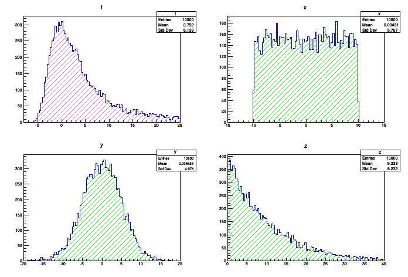

```python
f = ROOT.TFile('ntuple_example.root', 'READ')

c = ROOT.TCanvas()
c.Divide(2,2)

c.cd(1)
f.n.SetFillStyle(3004)
f.n.SetFillColor(ROOT.kPink+6)
f.n.Draw("t>>t(100,-8,25)","","COLZ")

# finish the drawing in each pad
c.cd(2)
f.n.SetFillColor(ROOT.kGreen)
f.n.Draw("x>>x(100,-15,15)","","COLZ")

c.cd(3)
f.n.Draw("y>>y(100,-20,20)","","COLZ")

c.cd(4)
f.n.Draw("z>>z(100, 0, 40)","","COLZ")

# Draw the Canvas
c.Draw()
```

Read the ntuple event by event and fill an histogram with the `x*y` of each event, only if `t` is positive

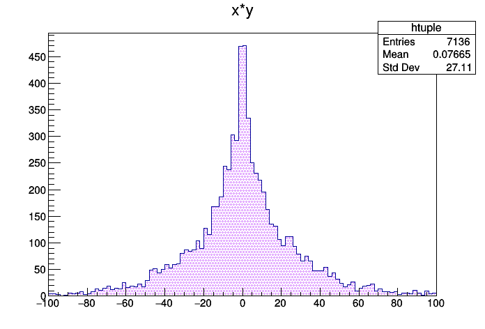

```python
htuple = ROOT.TH1F("htuple","x*y",100,-100,100)

# Loop over all the events
for evt in f.n:

    if evt.t > 0:
        # Fill the histo with x*y
        htuple.Fill(evt.x*evt.y)

htuple.SetFillStyle(3015)
htuple.SetFillColor(ROOT.kViolet-4)


c1 = ROOT.TCanvas()
htuple.Draw()
c1.Draw()
```

## Writing and reading TTree

### TTree with plain types

We are using the same values than in the previous `TNtuple` section to create a `TTree`.

**IMPORTANT NOTE**: A TTree uses variables to fill it, which assigns to the corresponding branch. The assignment is done using pointers in C++, which facilitates the serialization of the object which is going to be stored. In python, a plain type (int, floats, ...) needs to mimic the address assignation by using a list, array or any python container. This can be accomplished by `array.array` or event better by `numpy.array`.

Close the file: you will reopen it later.

```python
filename_tree = "ttree_example.root"

# Open the file
ftree = ROOT.TFile(filename_tree,"RECREATE")

# Here create the TTree
tree = ROOT.TTree("tree","Tree with plain types")

# Declare the variables to be assigned to the TTree
# Remember to use arrays and initialize at least 1 element
az = np.array([0],'f')
ay = np.array([0],'f')
ax = np.array([0],'f')
at = np.array([0],'f')

# Assign the variables to the branches
# we are using same names for the branches: x,y,z,t
tree.Branch("t",at,"t/F")
tree.Branch("x",ax,"x/F")
tree.Branch("y",ay,"y/F")
tree.Branch("z",az,"z/F")


# Fill the TTree
N = 10000
for i in xrange(N):
    # Assign the values to the corresponding variables,
    # Use the vectors already filled: x[i], y[i], z[i] and t[i]
    az[0] = z[i]
    ay[0] = y[i]
    ax[0] = x[i]
    at[0] = t[i]

    # Remember to fill the tree before ending
    tree.Fill()

# Here write the ntuple on the file and close the file
tree.Write()

ftree.Close()
```

```python
! rootls -t ttree_example.root
```

```
TTree  Dec 15 16:10 2019 tree  "Tree with plain types"
  t  "t/F"  40136
  x  "x/F"  40136
  y  "y/F"  40136
  z  "z/F"  40136
```

Access the created tree and draw all the elements. You can re-use the code from the ntuple.

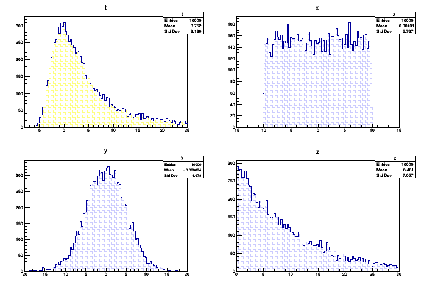

```python
f2 = ROOT.TFile('ttree_example.root')
c2 = ROOT.TCanvas()
c2.Divide(2,2)

# Create all the 4 pads and draw the same histograms than in the TNtuple case

c2.cd(1)
f2.tree.SetFillStyle(3022)
f2.tree.SetFillColorAlpha(ROOT.kYellow, 0.5)
f2.tree.Draw("t>>t(100,-8,25)")

# finish the drawing in each pad
c2.cd(2)
f2.tree.SetFillColorAlpha(ROOT.kBlue, 0.2)
f2.tree.Draw("x>>x(100,-15,15)")

c2.cd(3)
f2.tree.Draw("y>>y(100,-20,20)")

c2.cd(4)
f2.tree.Draw("z>>z(100, 0, 30)")

# Draw the Canvas
c2.Draw()
```

### TTree with generic objects

So far, we did not use the full potential of the `TTree`. Any object could be stored in a TTree, not only plain types. Let's store a similar information than before, but in a more compact way using STL vectors

```python
filename_tree = "ttree_example.root"

# Update the file with a new tree but without destroy previous data
f2tree = ROOT.TFile(filename_tree, 'UPDATE')

# Here create the new TTree
tree2 = ROOT.TTree("tree_vector","Tree with complex objects")

# Declare the variables to be assigned to the TTree: a 4-dimensional
# vector mimicking tracks
pt_vec=ROOT.std.vector(float)()
phi_vec=ROOT.std.vector(float)()
eta_vec=ROOT.std.vector(float)()
mass_vec=ROOT.std.vector(float)()

# Declare a helper list
vec_list= [ pt_vec, phi_vec, eta_vec, mass_vec ]

# Assign those variables to the TTree branches, remember use TTree.Branch method

tree2.Branch('pt', pt_vec)
tree2.Branch('phi', phi_vec)
tree2.Branch('eta', eta_vec)
tree2.Branch('mass', mass_vec)


# Create N-random pions
N= 1000

mass=0.13957
pt=np.random.exponential(10,N)
eta=np.random.uniform(-3,3,N)
phi=np.random.uniform(0,2.0*np.pi,N)

# How many pions per event (20 in average)
nPart = np.random.poisson(20,N)

# Fill the TTree
for i in xrange(N):
    # clear the vectors and prepare them (use reserve) for the next iteration
    # IMPORTANT!! Clear the vectors, otherwise you are storing all the accumulated info
    pt_vec.clear(); pt_vec.reserve(nPart[i])
    phi_vec.clear(); phi_vec.reserve(nPart[i])
    eta_vec.clear(); eta_vec.reserve(nPart[i])
    mass_vec.clear(); mass_vec.reserve(nPart[i])

    # Store each particle in the vector
    for j in xrange(nPart[i]):
        pt_vec.push_back(pt[i])
        phi_vec.push_back(phi[i])
        eta_vec.push_back(eta[i])
        mass_vec.push_back(mass)

    # fill the tree
    tree2.Fill()

# Here write the ntuple on the file and close the file
tree2.Write()
f2tree.Close()
```

```python
! rootls -t ttree_example.root
```

```
TTree  Dec 15 16:10 2019 tree         "Tree with plain types"
  t  "t/F"  40136
  x  "x/F"  40136
  y  "y/F"  40136
  z  "z/F"  40136
TTree  Dec 15 16:10 2019 tree_vector  "Tree with complex objects"
  pt    "pt"    94112
  phi   "phi"   94116
  eta   "eta"   94116
  mass  "mass"  94120
```

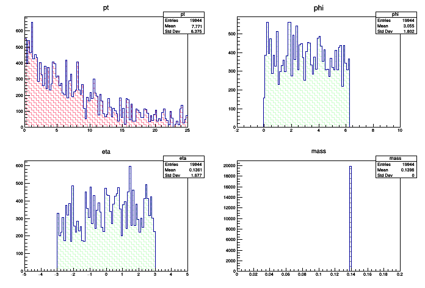

```python
f3 = ROOT.TFile('ttree_example.root')
c3 = ROOT.TCanvas()
c3.Divide(2,2)

# Create all the 4 pads and draw the same histograms than in the TNtuple case

c3.cd(1)
f3.tree_vector.SetFillStyle(3022)
f3.tree_vector.SetFillColorAlpha(ROOT.kPink, 0.5)
f3.tree_vector.Draw("pt>>pt(100,0,25)")

# finish the drawing in each pad
c3.cd(2)
f3.tree_vector.SetFillColorAlpha(ROOT.kGreen, 0.2)
f3.tree_vector.Draw("phi>>phi(100,-2,10)")

c3.cd(3)
f3.tree_vector.Draw("eta>>eta(100,-5,5)")

c3.cd(4)
f3.tree_vector.SetFillColorAlpha(ROOT.kBlack, 0.5)
f3.tree_vector.Draw("mass>>mass(100, 0, 0.2)")

# Draw the Canvas
c3.Draw()
```

As extra you can try to plot again all the values stored and compare them with the previous plain type example

### Reading TTree with generic objects

The reading exercise is going to be prepared using the example from the slide `"Filling a Tree with Objects"`. Execute the next cell to create the input file you need

```python
fname_objects="vector_collection.root"
f=ROOT.TFile(fname_objects,"RECREATE")
t=ROOT.TTree("tree_tracks","Tree with pseudo-particles")
particles= ROOT.std.vector(ROOT.std.vector(float))()

t.Branch("tracks", particles)

# pi+/pi- mass
mass = 0.13957
for i in xrange(5000):
    nPart = rndm.Poisson(20)
    particles.clear(); particles.reserve(nPart)
    for j in xrange(nPart):
        cpar=ROOT.std.vector(float)();
        pt = rndm.Exp(10); eta = rndm.Uniform(-3,3); phi = rndm.Uniform(0, 2*ROOT.TMath.Pi())
        cpar.push_back(pt); cpar.push_back(eta); cpar.push_back(phi); cpar.push_back(mass);
        particles.push_back(cpar)
    t.Fill()
t.Write()
f.Close()
```

Retrieve the vector of particles, i.e., a 4-vector with (pt.eta,phi,mass), and plot the **momentum** (not pt!!), the **eta**, the **total energy available at each event** and the **number of particles per event**.

Trick: you can obtain in [wikipedia](https://en.wikipedia.org/wiki/Pseudorapidity) the definition of eta (pseudorapidity) and how to relate the transverse momentum, eta and phi with the cartesian momentum.

```python
! rootls -t vector_collection.root
```

```
TTree  Dec 15 16:13 2019 tree_tracks  "Tree with pseudo-particles"
  tracks  "tracks"  2077128
```

```python
# Open the file in read-only mode
f = ROOT.TFile.Open('vector_collection.root')

# Obtain the tree where tracks are, "tree_tracks"

new_tree = f.Get("tree_tracks")
# Create the needed histograms
hmom=ROOT.TH1F("hmom","Momentum;p [GeV/c];Entries",100,0,150)
heta=ROOT.TH1F("eta","#eta",100,-3.3,3.3)
henergy=ROOT.TH1F("total energy","Energy per event;#SigmaE [GEV/c^{2}];Events",100,0,2500)
hn=ROOT.TH1I("total particles","Pions per event;N_{pions};Events}",50,-0.5,49.5)

# Some useful functions
# momentum (use a lambda function to obtain the momentum of each particle)
momentum = lambda evt: evt[0]*np.cosh(evt[1])

# energy (use a lambda function to obtain the energy of each particle)
energy = lambda evt: np.sqrt(momentum(evt)**2 + evt[3]**2)


# Remember: each element of the vector tracks contain a 4-vector
# (pt,eta,phi,mass)

# Loop over particles
for evt in new_tree:
    # Obtain the total number of particles in the event
    ntot=evt.tracks.size()
    # Loop over the particles to fill
    etot=0.0
    for j in xrange(ntot):
        # Calculate the momentum and fill the momentum histo
        p = momentum(evt.tracks[j])
        hmom.Fill(p)
        # Fill the eta histogram
        myeta = evt.tracks[j]
        heta.Fill(myeta[1])
        # Sum-up the contribution of this particle in the energy
        # (Note: here is using the lambda function implemented before)
        etot += energy(evt.tracks[j])
    # Fill the "per event" histograms
    henergy.Fill(etot)
    hn.Fill(ntot)
```

Finally plot all the histograms: momentum, eta, energy and number of particles

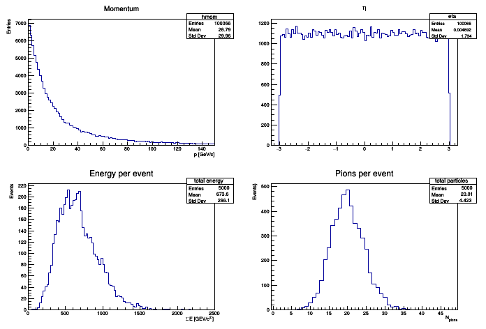

```python
f4 = ROOT.TFile('vector_collection.root')
c4 = ROOT.TCanvas()
c4.Divide(2,2)
# As usual ...

# Create all the 4 pads and draw the same histograms than in the TNtuple case

c4.cd(1)
hmom.Draw()

c4.cd(2)
heta.Draw()

c4.cd(3)
henergy.Draw()


c4.cd(4)
hn.Draw()
# Draw the Canvas
c4.Draw()
```